# Replication of Why Do We Hate Hypocrites? Evidence for a Theory of False Signaling by Jillian Jordan, Roseanna Sommers, Paul Bloom & David Rand (2017, Psychological Science)

Luiza A. Santos (lsantos1@stanford.edu)

December 11, 2018

## Introduction

As a graduate student in Psychology, I am interested in exploring the processes underlying moral cognition. One particular area of interest is to examine how people perceive different types of moral transgressions. Related to this topic, Jordan and colleagues (2017) sought to explain why hypocrites (i.e., those who condemn transgressions they engage in) are more disliked than individuals who commit the same transgressions without condemning them. The authors hypothesized that hypocrites are disliked because their condemnation falsely signals their own moral goodness. Although all five studies reported in this paper support this prediction in different ways, Study 4 is the only one that explicitly focuses on the false-signaling element and is, therefore, critical to the article’s key claim. Thus, Study 4’s results will be the target of this replication.

As the authors made all data and materials publicly available via the Open Science Framework, potential replication difficulties have been significantly decreased.

Link to repository: https://github.com/SantosLuiza/Replication-Project

Link to original paper: https://github.com/SantosLuiza/Replication-Project/blob/master/original_paper/jordan2016.pdf

Link to preregistration: https://osf.io/e46j7/

## Methods

### Planned Sample

In the original paper, Jordan and colleagues recruited 457 subjects online using Amazon Mturk. For this replication project, we will run the study’s original sample size (approximately 150 participants per condition) with two conditions, for a total of 300 participants. As the control condition isn’t crucial for the study’s central claim, we will drop it from this replication.

We will analyze responses from all subjects who have unique IP addresses and have evaluated all the vignettes.

### Materials

We will use the same materials employed by original authors. All the experimental materials for this study are available online and can be accessed here: https://osf.io/2r8ab/.

Each participant will be presented with four vignettes (in random order), about downloading music illegally, evading jury duty, ignoring phone calls from one’s mother, and wasting paper by printing documents single-sided.

In each vignette, a target character discusses an acquaintance’s moral transgression and then privately goes on to engage in the same transgression. In a two-condition, between-subjects design, we will manipulate whether, before engaging in the relevant moral transgression, the target (a) condemned the violation (traditional-hypocrite condition), or (b) condemned the violation but explicitly negated any signaling value of the condemnation (honest-hypocrite condition).

After reading the vignettes, participants will be asked to evaluate the target.

### Procedure

We will follow the original paper’s procedure precisely. Below is a detailed description of the study design as outlined by original authors.

> “Each vignette described a conversation between two characters: a target (whom subjects would later evaluate) and a friend (whom subjects would not evaluate). In all conditions, this conversation began with the target and the friend discussing a mutual acquaintance. In this discussion, the friend mentioned that the mutual acquaintance often engaged in a particular moral transgression.”

> “In the traditional-hypocrite condition, the target responded to the friend by condemning the transgression. In the honest-hypocrite condition, the target responded to the friend by stating that he or she believed the behavior in question to be morally wrong but sometimes behaved that way anyway. (…) Shortly after this conversation ended, in all conditions, the target went on to commit the relevant violation.

> For example, here is the full text for a scenario about downloading music illegally. In this scenario, Becky is the target character, and Amanda is the friend. In all conditions, the vignette began as follows:

```
Becky and her friend Amanda are discussing a mutual acquaintance. Amanda mentions that the acquaintance often downloads music illegally from the Internet.
```

> In the traditional-hypocrite condition, the scenario continued with

```
Becky says that she thinks it is morally wrong to download music illegally from the Internet. Shortly after their conversation, Becky goes online, and downloads music illegally.
```

> In the honest-hypocrite condition, the passage instead continued with

```
Becky says that she thinks it is morally wrong to download music illegally from the Internet, but that she sometimes does it anyway. Shortly after their conversation, Becky goes online, and downloads music illegally.
```

Link to paradigm: https://stanforduniversity.qualtrics.com/jfe/form/SV_5nJWFtwbmrNq3jL

### Analysis Plan

To test the authors’ prediction, we will conduct a pairwise comparison investigating the effect of condition on positive evaluations of the targets across the vignettes.

In order to confirm that the honest hypocrite manipulation fully eliminates disapproval of hypocrisy, pairwise comparisons should reveal that traditional hypocrites are evaluated more negatively than honest hypocrites.

Following the original article criteria, we will exclude from the analysis participants who have identical IP addresses and those who do not complete the survey.

### Differences from Original Study

The only anticipated difference from the original study is that, in this replication, we won’t be running the control condition.

## Results

### Data preparation

Data preparation following the analysis plan.

```r
###Import data and Load Relevant Libraries and Functions
library(tidyverse)
```

```r
library(ggplot2)
library(psych)
library(effsize)
library(corrr)
library(reshape2)
library(lme4)
library(pwr)
Final_data <- read_csv("Final_data.csv")
head(Final_data)
```

```
## # A tibble: 6 x 45
##   Traditional_tru~ Traditional_hyp~ Traditional_lik~ Traditional_hon~
##              <int>            <int>            <int>            <int>
## 1               41               40               41               41
## 2               32               93               39               40
## 3               NA               NA               NA               NA
## 4               78               51               52               85
## 5               25               64               52               26
## 6               NA               NA               NA               NA
## # ... with 41 more variables: Traditional_good_music <int>,
## #   Traditional_trust_jury <int>, Traditional_hypo_jury <int>,
## #   Traditional_like_jury <int>, Traditional_honest_jury <int>,
## #   Traditional_good_jury <int>, Traditional_trust_phone <int>,
## #   Traditional_hypo_phone <int>, Traditional_like_phone <int>,
## #   Traditional_honest_phone <int>, Traditional_good_phone <int>,
## #   Traditional_trust_print <int>, Traditional_hypo_print <int>,
## #   Traditional_like_print <int>, Traditional_honest_print <int>,
## #   Traditional_good_print <int>, Honest_trust_music <int>,
## #   Honest_hypo_music <int>, Honest_like_music <int>,
## #   Honest_honest_music <int>, Honest_good_music <int>,
## #   Honest_trust_jury <int>, Honest_hypo_jury <int>,
## #   Honest_like_jury <int>, Honest_honest_jury <int>,
## #   Honest_good_jury <int>, Honest_trust_phone <int>,
## #   Honest_hypo_phone <int>, Honest_like_phone <int>,
## #   Honest_honest_phone <int>, Honest_good_phone <int>,
## #   Honest_trust_print <int>, Honest_hypo_print <int>,
## #   Honest_like_print <int>, Honest_honest_print <int>,
## #   Honest_good_print <int>, Age <chr>, Gender <chr>, Income <chr>,
## #   Education <chr>, `Random ID` <int>
```

```r
sem <- function(x) {sd(x, na.rm=TRUE) / sqrt(sum(!is.na((x))))}
ci <- function(x) {sem(x) * 1.96}
```

#### Data exclusion / filtering

```r
##Delete subjects who have identical IP adresses or who have not completed the survey
#All subjects in this study had unique IP adresses and completed the survey
```

### Data Analysis

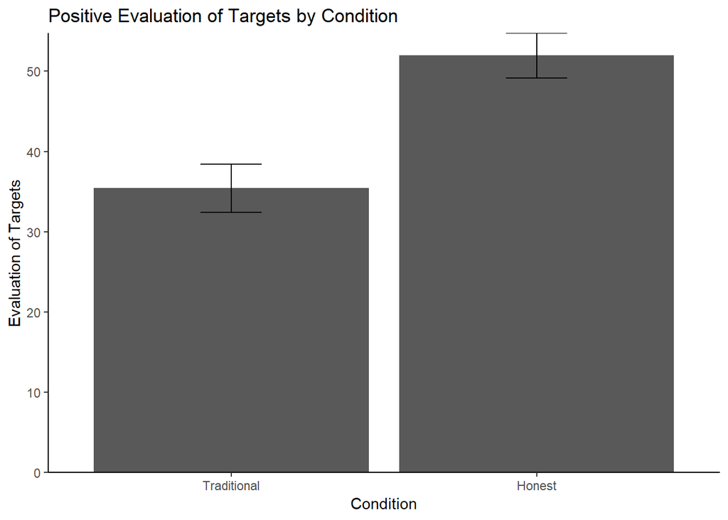

```r
###Preparing data for analysis
Final_data <- Final_data %>%
  gather(Condition, Evaluation, starts_with("Traditional"), starts_with("Honest")) %>%
  separate(Condition, into = c("Condition", "Variable", "Scenario"), sep = "_")

F_data_small <- filter(Final_data, Variable != "hypo") #filtering out hypocrite measures

###Demographics

F_data_g <- Final_data %>%
 group_by(Gender) %>%
 summarise(gender_count=n()/40)

F_data_age <- Final_data %>%
 group_by(Age) %>%
 summarise(age_count=n()/40)

F_data_c <- Final_data %>%
 group_by(Condition) %>%
 summarise(condition_count=n()/40)

F_data_dem <- F_data_small %>%
  select(`Random ID`, Condition, Variable, Evaluation, Age, Gender)

Sub_means_dem <- F_data_dem %>%
  group_by(Gender, Condition) %>%
  summarise(sub_mean = mean(Evaluation, na.rm = TRUE))

Grand_means_dem <- Sub_means_dem %>%
  group_by(Condition) %>%
  summarise(grand_mean_evaluation = mean(sub_mean, na.rm=TRUE),
            ci_eval = ci(sub_mean))

###Reverse scoring "hypocrite" variable
#B_data <- mutate(B_data, Evaluation = ifelse(B_data$Variable == "hypo", 100 - B_data$Eval, B_data$Eval))

###Analyzing differences in means for target evaluation

F_data_condition <- F_data_small %>%
  select(`Random ID`, Condition, Variable, Evaluation)

Sub_means <- F_data_condition %>%
  group_by(`Random ID`, Condition) %>%
  summarise(sub_mean = mean(Evaluation, na.rm = TRUE))

Grand_means <- Sub_means %>%
  group_by(Condition) %>%
  summarise(grand_mean_evaluation = mean(sub_mean, na.rm=TRUE),
            ci_eval = ci(sub_mean),
            sd=sd(sub_mean,  na.rm = TRUE))

sem_eval = sem(Sub_means$sub_mean)


plot <- ggplot(Grand_means, aes(x = Condition, y = grand_mean_evaluation)) +
  ggtitle("Positive Evaluation of Targets by Condition") +
  geom_bar(stat="identity") + ylab("Evaluation of Targets") +
  geom_errorbar(aes(ymin=grand_mean_evaluation-ci_eval, ymax=grand_mean_evaluation+ci_eval), width = .2) +
  scale_x_discrete(limit = c("Traditional", "Honest")) +
  scale_y_continuous(expand = c(0,0)) +
  theme_bw() + theme(panel.border = element_blank(), panel.grid.major = element_blank(), panel.grid.minor = element_blank(), axis.line = element_line(colour = "black"))

plot
```

Original plot for comparison:

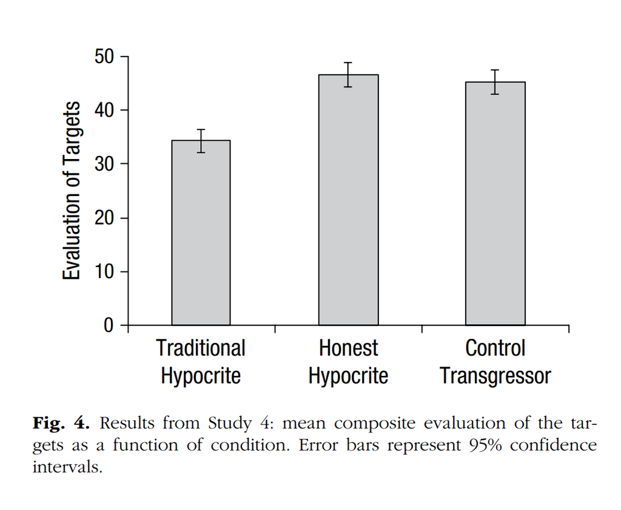

### Confirmatory analysis

The analyses as specified in the analysis plan.

```r
### Key Statistics: Pairwise comparison for target evaluation
Eval_test <- t.test(sub_mean ~ Condition, data = Sub_means)
Eval_test
```

```
##
##  Welch Two Sample t-test
##
## data:  sub_mean by Condition
## t = 7.8762, df = 296.55, p-value = 6.428e-14
## alternative hypothesis: true difference in means is not equal to 0
## 95 percent confidence interval:
##  12.39496 20.65237
## sample estimates:
##      mean in group Honest mean in group Traditional
##                  51.97091                  35.44724
```

### Exploratory analysis

Exploratory analysis. Aggregating by scenario and examining hypocrisy ratings across conditions.

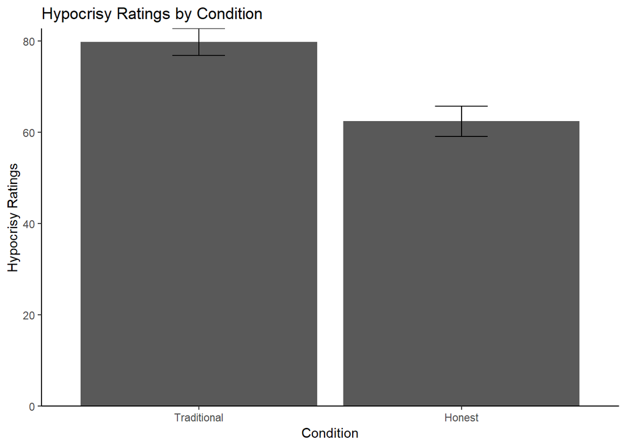

```r
###Extra: Pairwise comparison for hypocrisy ratings

###Analyzing differences in means for hypocrisy ratings

F_data_hypo <- filter(Final_data, Variable == "hypo")

F_data_hypo <- F_data_hypo %>%
  select(`Random ID`, Condition, Variable, Evaluation)

Sub_means_hypo <- F_data_hypo %>%
  group_by(`Random ID`, Condition) %>%
  summarise(sub_mean = mean(Evaluation, na.rm = TRUE))

Grand_means_hypo <- Sub_means_hypo %>%
  group_by(Condition) %>%
  summarise(grand_mean_evaluation = mean(sub_mean, na.rm=TRUE),
            ci_hypo = ci(sub_mean),
            sd=sd(sub_mean,  na.rm = TRUE))


###Plot
plot_hypo <- ggplot(Grand_means_hypo, aes(x = Condition, y = grand_mean_evaluation)) +
   geom_bar(stat="identity") +
  ggtitle("Hypocrisy Ratings by Condition") +
  ylab("Hypocrisy Ratings") +
  geom_errorbar(aes(ymin=grand_mean_evaluation-ci_hypo, ymax=grand_mean_evaluation+ci_hypo), width = .2) +
  scale_y_continuous(expand = c(0,0)) +
  scale_x_discrete(limit = c("Traditional", "Honest")) +
  theme_bw() + theme(panel.border = element_blank(), panel.grid.major = element_blank(), panel.grid.minor = element_blank(), axis.line = element_line(colour = "black"))

plot_hypo
```

```r
###Pairwise comparison for hypocrisy ratings
Eval_test_hypo <- t.test(sub_mean ~ Condition, data = Sub_means_hypo)
Eval_test_hypo
```

```
##
##  Welch Two Sample t-test
##
## data:  sub_mean by Condition
## t = -7.6235, df = 292.13, p-value = 3.482e-13
## alternative hypothesis: true difference in means is not equal to 0
## 95 percent confidence interval:
##  -21.82856 -12.87053
## sample estimates:
##      mean in group Honest mean in group Traditional
##                  62.39397                  79.74351
```

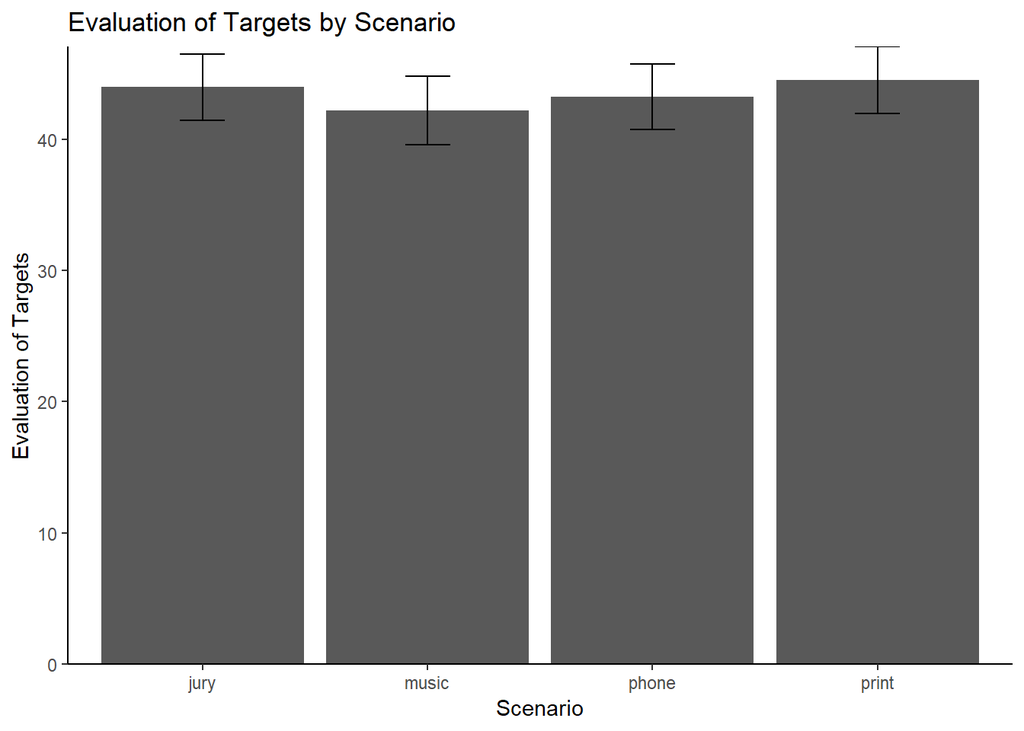

```r
###Aggreating by scenario

F_data_scenario <- F_data_small %>%
  select(`Random ID`, Condition, Scenario, Variable, Evaluation)

Sub_means_scenario <- F_data_scenario %>%
  group_by(`Random ID`, Condition, Scenario) %>%
  summarise(sub_mean = mean(Evaluation, na.rm = TRUE))

Grand_means_scenario <- Sub_means_scenario %>%
  group_by(Scenario) %>%
  summarise(grand_mean_evaluation = mean(sub_mean, na.rm=TRUE),
           ci_sce = ci(sub_mean))

plot_scenario <- ggplot(Grand_means_scenario, aes(x = Scenario, y = grand_mean_evaluation)) +
  ggtitle("Evaluation of Targets by Scenario") +
  geom_bar(stat="identity") +
  ylab("Evaluation of Targets") +
  geom_errorbar(aes(ymin=grand_mean_evaluation-ci_sce, ymax=grand_mean_evaluation+ci_sce), width = .2) +
  scale_y_continuous(expand = c(0,0)) +
  theme_bw() +
  theme(panel.border = element_blank(), panel.grid.major = element_blank(), panel.grid.minor = element_blank(), axis.line = element_line(colour = "black"))

plot_scenario
```

```r
### Coherence of participants' responses across variables
F_data_variable <- F_data_small %>%
  select(`Random ID`, Condition, Variable, Evaluation)

Sub_means_variable <- F_data_variable %>%
  group_by(`Random ID`, Condition, Variable) %>%
  summarise(sub_mean = mean(Evaluation, na.rm = TRUE))

Grand_means_variable <- Sub_means_variable %>%
  group_by(Variable) %>%
  summarise(grand_mean_evaluation = mean(sub_mean, na.rm=TRUE),
            ci_variable = ci(sub_mean))

var <- F_data_variable %>%
  group_by_at(vars(-Evaluation)) %>%  # group by everything other than the value column.
  mutate(row_id=1:n()) %>% ungroup() %>%  # build group index
  spread(key=Variable, value=Evaluation) %>%    # spread
  select(-row_id) %>%  # drop the index
  select(-`Random ID`) %>%
   select(-Condition)

inter_item <- var %>% correlate()
```

```
##
## Correlation method: 'pearson'
## Missing treated using: 'pairwise.complete.obs'
```

```r
psych::alpha(x = var)$total$std.alpha
```

```
## [1] 0.9352767
```

#### Actual Sample

As anticipated, we collected data from 300 Mturkers (54% male). All participants had unique IP addresses and completed the survey, therefore there were no exclusions.

## Discussion

### Summary of Replication Attempt

This project’s results show a successful replication of Study 4 of Jordan 2017. Similarly to the original study, we found high interitem reliability among the four evaluation variables (*a* = .94), and we averaged these ratings to create a composite scale.

The original paper’s primary statistical analysis was replicated as traditional hypocrites (M = 35.45, SD = 19.04) were judged more negatively than honest hypocrites (M = 51.97, SD = 17.23), mean difference = 16.52, 95% CI = [12.39, 20.65], t(296) = 7.88, p < .001, d = 0.91.

Moreover, exploratory pairwise comparisons showed that, just like the original study, traditional hypocrites (M = 79.74, SD = 18.95) were seen as more hypocritical than honest hypocrites (M = 62.39, SD =20.31), (t(292) = -7.62, p < .001, d = .88).

### Commentary

Overall, Jordan 2017 Study 4’s results were successfully replicated. All results were faithful to the ones reported in the original paper.